# Assignment

### Answer (1)

```r
set.seed(20077)
library(energy)
library(Ball)
library(RANN)
library(boot)
B <- 100
m <- 30##sample size of X
n <- 30##sample size of Y
L <- c(m,n)
p_energy <- p_ball<- p_NN <-numeric(B)
alpha <- 0.1


T_n <- function(z, ix, len,k) {
  n_1 <- len[1];
  n_2 <- len[2];
  n <- n_1 + n_2
  if(is.vector(z)) z <- data.frame(z,0);
  z <- z[ix, ];
  NN <- nn2(data=z, k=k+1)
  block_1 <- NN$nn.idx[1:n_1,-1]
  block_2 <- NN$nn.idx[(n_1+1):n,-1]
  count_1 <- sum(block_1 < n_1 + 0.5);
  count_2 <- sum(block_2 > n_1+0.5)
  (count_1 + count_2) / (k * n)
}



for(b in 1:B){
  X <- rnorm(m,0.3,1)
  Y <- rnorm(n,0.8,1)
  Z <- c(X,Y)
  boot.obs <- eqdist.etest(Z, sizes=L, R=99)
  p_energy[b] <- boot.obs$p.value
  p_ball[b] <- bd.test(x = X, y = Y,num.permutations=99)$p.value

  boot.obj <- boot(data = Z, statistic = T_n, R = 99,
  sim = "permutation", len = L,k=3)
  test_re <- c(boot.obj$t0,boot.obj$t)
  p_NN[b] <- mean(test_re>=test_re[1])
}

print(power_NN<-mean(p_NN<alpha))##power of NN method
```

```
## [1] 0.01
```

```r
print(power_energy<-mean(p_energy<alpha))##  power of energy method
```

```
## [1] 0.01
```

```r
print(power_ball<-mean(p_ball<alpha))## power of ball method
```

```
## [1] 0.01
```

### Answer (2)

```r
set.seed(20077)
library(energy)
library(Ball)
library(RANN)
library(boot)
B <- 100
m <- 30##sample size of X
n <- 30##sample size of Y
L <- c(m,n)
p_energy <- p_ball<- p_NN <-numeric(B)
alpha <- 0.1


T_n <- function(z, ix, len,k) {
  n_1 <- len[1];
  n_2 <- len[2];
  n <- n_1 + n_2
  if(is.vector(z)) z <- data.frame(z,0);
  z <- z[ix, ];
  NN <- nn2(data=z, k=k+1)
  block_1 <- NN$nn.idx[1:n_1,-1]
  block_2 <- NN$nn.idx[(n_1+1):n,-1]
  count_1 <- sum(block_1 < n_1 + 0.5);
  count_2 <- sum(block_2 > n_1+0.5)
  (count_1 + count_2) / (k * n)
}



for(b in 1:B){
  X <- rnorm(m,0.3,2)
  Y <- rnorm(n,0.8,1.5)
  Z <- c(X,Y)
  boot.obs <- eqdist.etest(Z, sizes=L, R=99)
  p_energy[b] <- boot.obs$p.value
  p_ball[b] <- bd.test(x = X, y = Y,num.permutations=99)$p.value

  boot.obj <- boot(data = Z, statistic = T_n, R = 99,
  sim = "permutation", len = L,k=3)
  test_re <- c(boot.obj$t0,boot.obj$t)
  p_NN[b] <- mean(test_re>=test_re[1])
}

print(power_NN<-mean(p_NN<alpha))##power of NN method
```

```
## [1] 0.01
```

```r
print(power_energy<-mean(p_energy<alpha))##  power of energy method
```

```
## [1] 0.01
```

```r
print(power_ball<-mean(p_ball<alpha))## power of ball method
```

```
## [1] 0.01
```

### Answer (3)

```r
set.seed(20077)
library(energy)
library(Ball)
library(RANN)
library(boot)
B <- 100
m <- 30##sample size of X
n <- 30##sample size of Y
L <- c(m,n)
p_energy <- p_ball<- p_NN <-numeric(B)
alpha <- 0.1


T_n <- function(z, ix, len,k) {
  n_1 <- len[1];
  n_2 <- len[2];
  n <- n_1 + n_2
  if(is.vector(z)) z <- data.frame(z,0);
  z <- z[ix, ];
  NN <- nn2(data=z, k=k+1)
  block_1 <- NN$nn.idx[1:n_1,-1]
  block_2 <- NN$nn.idx[(n_1+1):n,-1]
  count_1 <- sum(block_1 < n_1 + 0.5);
  count_2 <- sum(block_2 > n_1+0.5)
  (count_1 + count_2) / (k * n)
}



for(b in 1:B){
  X <- rt(m,df=1)
  Y_1 <- rnorm(n,0,1)
  Y_2 <- rnorm(n,0,0.8)
  Y <- numeric(n)
  p <- runif(n)
  for(i in 1:n){
    if(p[i]<0.5) {Y[i]=Y_1[i]}
    else{Y[i]=Y_2[i]}
  }##generate mixture of two normal   distributions
  Z <- c(X,Y)
  boot.obs <- eqdist.etest(Z, sizes=L, R=99)
  p_energy[b] <- boot.obs$p.value
  p_ball[b] <- bd.test(x = X, y = Y,num.permutations=99)$p.value

  boot.obj <- boot(data = Z, statistic = T_n, R = 99,
  sim = "permutation", len = L,k=3)
  test_re <- c(boot.obj$t0,boot.obj$t)
  p_NN[b] <- mean(test_re>=test_re[1])
}

print(power_NN<-mean(p_NN<alpha))##power of NN method
```

```
## [1] 0.99
```

```r
print(power_energy<-mean(p_energy<alpha))##  power of energy method
```

```
## [1] 1
```

```r
print(power_ball<-mean(p_ball<alpha))## power of ball method
```

```
## [1] 0.99
```

### Answer (4)

```r
set.seed(20077)
library(energy)
library(Ball)
library(RANN)
library(boot)
B <- 10
m <- 10##sample size of X
n <- 100##sample size of Y
L <- c(m,n)
p_energy <- p_ball<- p_NN <-numeric(B)
alpha <- 0.1

T_n <- function(z, ix, len,k) {
  n_1 <- len[1];
  n_2 <- len[2];
  n <- n_1 + n_2
  if(is.vector(z)) z <- data.frame(z,0);
  z <- z[ix, ];
  NN <- nn2(data=z, k=k+1)
  block_1 <- NN$nn.idx[1:n_1,-1]
  block_2 <- NN$nn.idx[(n_1+1):n,-1]
  count_1 <- sum(block_1 < n_1 + 0.5);
  count_2 <- sum(block_2 > n_1+0.5)
  (count_1 + count_2) / (k * n)
}



for(b in 1:B){
  X <- rnorm(m,0,1)
  Y <- rnorm(n,0,1)
  Z <- c(X,Y)
  boot.obs <- eqdist.etest(Z, sizes=L, R=999)
  p_energy[b] <- boot.obs$p.value
  p_ball[b] <- bd.test(x = X, y = Y,num.permutations=999)$p.value

  boot.obj <- boot(data = Z, statistic = T_n, R = 999,
  sim = "permutation", len = L,k=3)
  test_re <- c(boot.obj$t0,boot.obj$t)
  p_NN[b] <- mean(test_re>=test_re[1])
}

print(power_NN<-mean(p_NN<alpha))##power of NN method
```

```
## [1] 0.1
```

```r
print(power_energy<-mean(p_energy<alpha))##  power of energy method
```

```
## [1] 0
```

```r
print(power_ball<-mean(p_ball<alpha))## power of ball method
```

```
## [1] 0
```

# 2020-11-17

### Question 1(9.4)

Implement a random walk Metropolis sampler for generating the standard Laplace distribution (see Exercise 3.2). For the increment, simulate from a normal distribution. Compare the chains generated when different variances are used for the proposal distribution. Also, compute the acceptance rates of each chain.

### Answer 1

The pdf of the standard Laplace distribution is
$$f_L(x)=\frac 12 e^{-|x|}$$
So
$$r(x_t,y)=\frac{f_L(Y)}{f_L(X_t)}=e^{|x_t|-|y|}$$

```r
set.seed(20077)
N <- 2000
Sample_Laplace <- function(n,X_1,sigma){
  p <- runif(n-1)
  Sample <- numeric(n)
  count <- 0
  Sample[1] <- X_1
  for(j in 1:(n-1)){
    delta <- rnorm(1,Sample[j],sigma)
    r <- exp(abs(Sample[j])-abs(delta))
    if (p[j]>r){
      Sample[j+1]<-Sample[j]
      count <- count+1
    }
    else{
      Sample[j+1] <- delta
    }
  }
  acceptrate <- count/n
  return(list(acceptrate=acceptrate,Sample=Sample))
}

sigma <- c(0.2,0.6,1.8,5.4)
L <- length(sigma)
x_1 <- 5
accept_rate <- numeric(L)

LSample1<-Sample_Laplace(N,x_1,sigma[1])
LSample2<-Sample_Laplace(N,x_1,sigma[2])
LSample3<-Sample_Laplace(N,x_1,sigma[3])
LSample4<-Sample_Laplace(N,x_1,sigma[4])


accept_rate[1] <- LSample1$acceptrate
accept_rate[2] <- LSample2$acceptrate
accept_rate[3] <- LSample3$acceptrate
accept_rate[4] <- LSample4$acceptrate


sample1 <- LSample1$Sample
sample2 <- LSample2$Sample
sample3 <- LSample3$Sample
sample4 <- LSample4$Sample



result <- matrix(c(sigma,accept_rate),nrow=L,ncol=2,dimnames=list(c("1","2","3","4"),c("sigma","accept rate")))
result
```

```
##   sigma accept rate
## 1   0.2      0.0795
## 2   0.6      0.1975
## 3   1.8      0.4430
## 4   5.4      0.7405
```

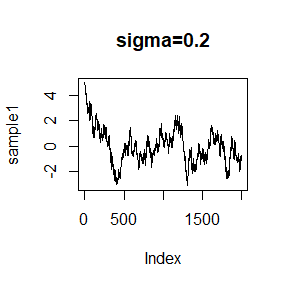

```r
plot(sample1,type = "l",main="sigma=0.2")
```

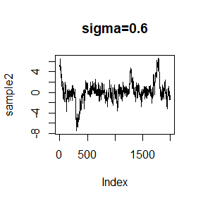

```r
plot(sample2,type = "l",main="sigma=0.6")
```

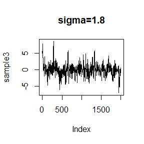

```r
plot(sample3,type = "l",main="sigma=1.8")
```

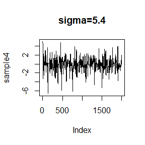

```r
plot(sample4,type = "l",main="sigma=5.4")
```

The second chain generated with $σ = 0.6$ is not converging apparently.But the rate of acceptance(0.1975) is in $[0.15,0.5]$.

In the third plot $(σ = 1.8)$ the chain is mixing well and converging to the target distribution.And the rate of acceptance(0.4430) is in $[0.15,0.5]$.

In the fourth plot, where $σ = 5.4$, the chain is mixing well and converging to the target distribution.But the rate of acceptance(0.7405) is not in $[0.15,0.5]$.

### Question 2

For Exercise 9.4, use the Gelman-Rubin method to monitor convergence of the chain, and run the chain until it converges approximately to the target distribution according to $\hat{R}<1.2$.

### Answer 2

```r
set.seed(20077)


Gelman_Rubin <- function(psi) {##the function from textbook
psi <- as.matrix(psi)
n <- ncol(psi)
k <- nrow(psi)
psi.means <- rowMeans(psi)
B <- n * var(psi.means)
psi.w <- apply(psi, 1, "var")
W <- mean(psi.w)
Var_hat <- W*(n-1)/n + (B/n)
R_hat <- Var_hat / W
return(R_hat)
}


N <- 2000
Sample_Laplace <- function(n,X_1,sigma){
  p <- runif(n-1)
  Sample <- numeric(n)
  Sample[1] <- X_1
  for(j in 1:(n-1)){
    delta <- rnorm(1,Sample[j],sigma)
    r <- exp(abs(Sample[j])-abs(delta))
    if (p[j]>r){
      Sample[j+1]<-Sample[j]
    }
    else{
      Sample[j+1] <- delta
    }
  }
  return(Sample)
}

sigma <- c(0.2,0.6,1.8,5.4)
L <- length(sigma)
x_1 <- 5
accept_rate <- numeric(L)
sample <- matrix(c(0:0),nrow=L,ncol=N)
for(l in 1:L){
  sample[l,] <- Sample_Laplace(N,x_1,sigma[l])
}

b <- 100
psi <- t(apply(sample, 1, cumsum))
psi_row <- nrow(psi)
psi_col <- ncol(psi)
for (i in 1:psi_row)
psi[i,] <- psi[i,] / (1:psi_col)
print(Gelman_Rubin(psi))
```

```
## [1] 1.132023
```

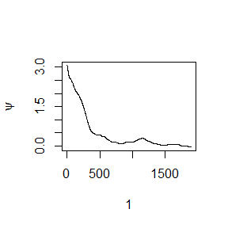

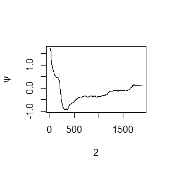

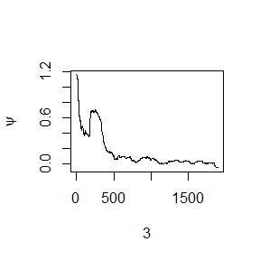

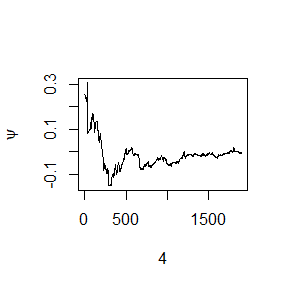

```r
#par(mfrow=c(2,2))
for (i in 1:L)
plot(psi[i, (b+1):N], type="l",
xlab=i, ylab=bquote(psi))
```

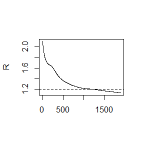

```r
#par(mfrow=c(1,1)) #restore default
#plot the sequence of R-hat statistics
Rhat <- rep(0, N)
for (j in (b+1):N)
Rhat[j] <- Gelman_Rubin(psi[,1:j])
plot(Rhat[(b+1):N], type="l", xlab="", ylab="R")
abline(h=1.2, lty=2)
```

```r
print(Gelman_Rubin(psi))
```

```
## [1] 1.132023
```

As we can see from the plot, when $n>1300$,$\hat{R}<1.2$.

### Question 3(11.4)

Find the intersection points $A(k)$ in $(0, \sqrt{k})$ of the curves
$$S_{k-1}(a)=P\left(t(k-1)>\sqrt{\frac{a^2(k-1)}{k-a^2}}\right)$$
and
$$S_{k}(a)=P\left(t(k)>\sqrt{\frac{a^2k}{k+1-a^2}}\right)$$
for $k = 4 : 25, 100, 500, 1000$, where $t(k)$ is a Student t random variable with $k$ degrees of freedom.

### Answer 3

```r
set.seed(20077)
df <- c(4:25,100,500,1000)
L <- length(df)
root_Bisection <- root_Brent <- numeric(L)
N <- 1000


h <- function(a,k){##the function need to get the root
  re <- 0
  if(k<2){re <- 0}
  else if(k<=a){re <- 0}
  else if(a<=0){re <- 0}
  else{
    re <-(1-pt(sqrt(a*a*(k-1)/(k-a^2)),df=k-1))-(1-pt(sqrt(a*a*k/(k+1-a^2)),df=k))
  }
  return(re)
}




for(i in 1:L){
  low <- 0.000001
  up <- sqrt(df[i])-0.000001
  root_Brent[i] <- uniroot(function(a) {(1-pt(sqrt(a*a*(df[i]-1)/(df[i]-a^2)),df=df[i]-1))-(1-pt(sqrt(a*a*df[i]/(df[i]+1-a^2)),df=df[i]))},
interval = c(0.000001, sqrt(df[i])-0.000001))$root

  y <- numeric(3)
  y[1] <- h(low,df[i])
  y[3] <- h(up,df[i])
  if(y[1]*y[3]>0){
    root_Bisection[i] <- sqrt(df[i])-0.000001
  }
  else{
    count <- 0
    low <- 0.00001
    up <- sqrt(df[i])-0.00001
    epsilon <- 0.00001
    r <- (up+low)/2
    y[2] <- h(r,df[i])
    while(abs(y[2])>epsilon && count < N){
      r <- (up+low)/2
      y[1] <- h(low,df[i])
      y[3] <- h(up,df[i])
      y[2] <- h(r,df[i])
      if(y[1]*y[2]>0){
        low <- r
      }
      else{
        up <- r
      }
      count <- count + 1
    }
    if(count<N){root_Bisection[i] <- r}
    else{root_Bisection[i]<-sqrt(df[i])-0.000001}
  }
}



result <- matrix(c(df,root_Bisection,root_Brent),nrow=L,ncol=3)
colnames(result)<-c("df","Bisection","Brent")
result
```

```
##         df Bisection     Brent
##  [1,]    4  1.492183  1.492103
##  [2,]    5  1.532926  1.533549
##  [3,]    6  1.562025  1.562768
##  [4,]    7  1.583832  1.584421
##  [5,]    8  1.602037  1.601182
##  [6,]    9  1.617187  1.614517
##  [7,]   10  1.624373  1.625406
##  [8,]   11  1.632401  1.634409
##  [9,]   12  1.637330  1.642026
## [10,]   13  1.647850  1.648511
## [11,]   14  1.651592  1.654174
## [12,]   15  1.664174  1.659121
## [13,]   16  1.656252  1.663442
## [14,]   17  1.675014  1.667288
## [15,]   18  1.657284  1.670736
## [16,]   19  1.668643  1.673841
## [17,]   20  1.677053  1.676589
## [18,]   21  1.682667  1.679139
## [19,]   22  1.685621  1.681461
## [20,]   23  1.686037  4.795831
## [21,]   24  1.684027  4.898978
## [22,]   25  1.718753  4.999999
## [23,]  100  5.000000  9.999999
## [24,]  500 11.180340 22.360679
## [25,] 1000 15.811388 31.622776
```

# 2020-11-24

### Answer 1

It’s obvious that
$$1=p^2+q^2+r^2+2pr+2qr+2pq=(p+q+r)^2$$
So $r=1-p-q$.

Observed data likelihood
$$L(p,q;n_{A.},n_{B.},n_{OO},n_{AB})=(p^2+2pr)^{n_{A.}}(q^2+2qr)^{n_{B.}}(r^2)^{n_{OO}}(2pq)^{n_{AB}}$$

Complete data likelihood
$$L(p,q;n_{AA},n_{AO},n_{BB},n_{BO},n_{OO},n_{AB})=(p^2)^{n_{AA}}(q^2)^{n_{BB}}(r^2)^{n_{OO}}(2pq)^{n_{AB}}(2pr)^{n_{AO}}(2qr)^{n_{BO}}$$
$$l(p,q;n_{AA},n_{AO},n_{BB},n_{BO},n_{OO},n_{AB})\\
=2n_{OO}\ln(r)+n_{AB}\ln(pq)+n_{A.}\ln(pr)+n_{B.}\ln(qr)+n_{AA}\ln(\frac{p}{r})+n_{BB}\ln(\frac{q}{r})+C\\
=(n_{AB}+n_{A.}+n_{AA})\ln(p)+(n_{AB}+n_{B.}+n_{BB})\ln(q)\\+(-n_{AA}+n_{A.}-n_{BB}+n_{B.}+2n_{OO})\ln(r)\\
=l(p,q|n_{AA},n_{A.},n_{BB},n_{B.},n_{OO},n_{AB})$$
And
$$n_{AA}|n_{A.},n_{B.},n_{AB},n_{OO}\sim B(n_{A.},\frac{p^2}{p^2+2pr})=B(n_{A.},\frac{p}{p+2r})$$

$$n_{BB}|n_{A.},n_{B.},n_{AB},n_{OO}\sim B(n_{B.},\frac{q^2}{q^2+2qr})=B(n_{B.},\frac{q}{q+2r})$$

E-step
$$E_{\hat\theta_m}[l(p,q|n_{AA},n_{A.},n_{BB},n_{B.},n_{OO},n_{AB})|n_{A.},n_{B.},n_{AB},n_{OO}]\\=
(n_{AB}+n_{A.}+n_{A.}\frac{\hat p_m}{2-\hat p_m-2\hat q_m})\ln(p)+(n_{AB}+n_{B.}+n_{B.}\frac{\hat q_m}{2-\hat q_m-2\hat p_m})\ln(q)\\+(-n_{A.}\frac{\hat p_m}{2-\hat p_m-2\hat q_m}+n_{A.}-n_{B.}\frac{\hat q_m}{2-\hat q_m-2\hat p_m}+n_{B.}+2n_{OO})\ln(r)\\
=(n_{AB}+n_{A.}\frac{2-2\hat q_m}{2-\hat p_m-2\hat q_m})\ln(p)+(n_{AB}+n_{B.}\frac{2-2\hat p_m}{2-\hat q_m-2\hat p_m})\ln(q)\\+(n_{A.}\frac{2-2\hat p_m-2\hat q_m }{2-\hat p_m-2\hat q_m}+n_{B.}\frac{2-2\hat p_m-2\hat q_m }{2-\hat q_m-2\hat p_m}+2n_{OO})\ln(1-p-q)$$

M-step
$$\hat p_{m+1}=\frac{n_{AB}}{2n}+\frac{n_{A.}}{n}\frac{1-\hat q_m}{2-\hat p_m-2\hat q_m}$$

$$\hat q_{m+1}=\frac{n_{AB}}{2n}+\frac{n_{B.}}{n}\frac{1-\hat p_m}{2-\hat q_m-2\hat p_m}$$

$$l_o=\ln L_o=c+2n_{OO}\ln r+n_{AB}\ln pq+n_{A.}\ln (2pr+p^2) +n_{B.}\ln(2qr+q^2)$$

```r
set.seed(20077)

n_At <- 444
n_Bt <- 132
n_OO <- 361
n_AB <- 63
n <- n_At+n_Bt+n_OO+n_AB


N <- 15
p_hat <- q_hat <- r_hat <- l<- numeric(N)##l is the log-likelihood without constant
p_hat[1] <- 0.2
q_hat[1] <- 0.3
r_hat[1] <- 1-p_hat[1]-q_hat[1]
l[1] <- 2*n_OO*log(r_hat[1])+n_AB*log(p_hat[1]*q_hat[1]) +n_At*log(2*p_hat[1]*r_hat[1]+p_hat[1]*p_hat[1])+n_Bt*log(2*q_hat[1]*r_hat[1]+q_hat[1]*q_hat[1])


for(j in 2:N){
  p_hat[j] <- n_AB/(2*n)+n_At/n*(1-q_hat[j-1])/(2*r_hat[j-1]+p_hat[j-1])
  q_hat[j] <- n_AB/(2*n)+n_Bt/n*(1-p_hat[j-1])/(2*r_hat[j-1]+q_hat[j-1])
  r_hat[j] <- 1-p_hat[j]-q_hat[j]
  l[j] <- 2*n_OO*log(r_hat[j])+n_AB*log(p_hat[j]*q_hat[j]) +n_At*log(2*p_hat[j]*r_hat[j]+p_hat[j]*p_hat[j])+n_Bt*log(2*q_hat[j]*r_hat[j]+q_hat[j]*q_hat[j])
}

re <- matrix(c(p_hat,q_hat,r_hat,l),nrow=N,ncol=4)
colnames(re) <- c("p_hat","q_hat","r_hat","log-likelihood")
re
```

```
##           p_hat     q_hat     r_hat log-likelihood
##  [1,] 0.2000000 0.3000000 0.5000000      -1435.629
##  [2,] 0.2905000 0.1127308 0.5967692      -1214.536
##  [3,] 0.2969564 0.1031958 0.5998478      -1213.493
##  [4,] 0.2975479 0.1027275 0.5997246      -1213.490
##  [5,] 0.2976254 0.1027067 0.5996679      -1213.490
##  [6,] 0.2976380 0.1027062 0.5996559      -1213.490
##  [7,] 0.2976402 0.1027062 0.5996536      -1213.490
##  [8,] 0.2976406 0.1027063 0.5996532      -1213.490
##  [9,] 0.2976406 0.1027063 0.5996531      -1213.490
## [10,] 0.2976407 0.1027063 0.5996531      -1213.490
## [11,] 0.2976407 0.1027063 0.5996531      -1213.490
## [12,] 0.2976407 0.1027063 0.5996531      -1213.490
## [13,] 0.2976407 0.1027063 0.5996531      -1213.490
## [14,] 0.2976407 0.1027063 0.5996531      -1213.490
## [15,] 0.2976407 0.1027063 0.5996531      -1213.490
```

As we can see,

the corresponding log-maximum likelihood values (for observed data) are increasing each step.

### Answer 2

```r
set.seed(20077)

formulas <- list(
mpg ~ disp,
mpg ~ I(1 / disp),
mpg ~ disp + wt,
mpg ~ I(1 / disp) + wt
)

l1 <- list
l2 <- list
l3 <- list
l4 <- list
Lm <- list(l1,l2,l3,l4)



for(i in 1:4){
mtcars.list <- split(mtcars, mtcars$cyl)
mylm <- function(x, form, me) lm(form, x, method = me)
Lm[[i]] <- lapply(mtcars.list, mylm, formulas[[i]], "qr")
}
Lm
```

```
## [[1]]
## [[1]]$`4`
##
## Call:
## lm(formula = form, data = x, method = me)
##
## Coefficients:
## (Intercept)         disp
##     40.8720      -0.1351
##
##
## [[1]]$`6`
##
## Call:
## lm(formula = form, data = x, method = me)
##
## Coefficients:
## (Intercept)         disp
##   19.081987     0.003605
##
##
## [[1]]$`8`
##
## Call:
## lm(formula = form, data = x, method = me)
##
## Coefficients:
## (Intercept)         disp
##    22.03280     -0.01963
##
##
##
## [[2]]
## [[2]]$`4`
##
## Call:
## lm(formula = form, data = x, method = me)
##
## Coefficients:
## (Intercept)    I(1/disp)
```

[output cut: 70 more lines]

```
## lm(formula = form, data = x, method = me)
##
## Coefficients:
## (Intercept)    I(1/disp)           wt
##      36.618     -759.107       -4.034
##
##
## [[4]]$`8`
##
## Call:
## lm(formula = form, data = x, method = me)
##
## Coefficients:
## (Intercept)    I(1/disp)           wt
##      22.626      260.622       -2.073
```

### Answer 3

```r
set.seed(20077)
trials <- replicate(
100,
t.test(rpois(10, 10), rpois(7, 10)),
simplify = FALSE
)
sapply(trials,function(x) x[["p.value"]])
```

```
##   [1] 0.985437251 0.532749698 0.978836835 0.315174248 0.921314446 0.883463167
##   [7] 0.041695770 0.677729563 0.202297483 0.545344206 0.665523144 0.259980805
##  [13] 0.023920878 0.487345080 0.876435804 0.509672161 0.838848368 0.446998095
##  [19] 0.859058448 0.409316885 0.388242960 0.612654353 0.544802154 0.825190873
##  [25] 0.306580430 0.160329094 0.896343277 0.042342135 0.919318402 0.651793115
##  [31] 0.693042837 0.936728270 0.082523322 0.611649307 0.237830492 0.110428523
##  [37] 0.329328737 0.317353496 0.011372117 0.923625392 0.959556164 0.846634922
##  [43] 0.793780421 0.773401258 0.041488281 0.523214941 0.592418287 0.210329726
##  [49] 0.025376608 0.761461181 0.459093531 0.459735669 0.845187015 0.871731461
##  [55] 0.792785717 0.870329055 0.561587111 0.495988755 0.765329628 0.500057597
##  [61] 0.128992747 0.417173828 0.847974230 0.160903238 0.525452017 0.356270195
##  [67] 0.438360326 0.561868122 0.280737888 0.007634617 0.116885139 0.384203925
##  [73] 0.140884429 0.039122398 0.105653487 0.954696645 0.081334754 0.604068420
##  [79] 0.419869549 0.758859628 0.433498606 0.375566910 0.200059841 0.275349327
##  [85] 0.161982604 0.419044571 0.084695829 0.425861900 0.462522012 0.084198442
##  [91] 0.558496009 0.901083724 0.599393977 0.523167903 0.837708038 0.125477390
##  [97] 0.101650633 0.645513361 0.665117035 0.380066180
```

### Answer 4

The parameter: function, data, function.value

```r
set.seed(20077)

new_lapply<-function(x,y,f,f.value,...){
  L <- list(x,y)
  l<-Map(unlist,L)
  re <- vapply(l,f,f.value,...)
  return(re)
}

z_1 <- c(26,43,51,57,28,73)
z_2 <- c(35,60,53,27,48,23)
new_lapply(z_1,z_2,sum,double(1))
```

```
## [1] 278 246
```

# 2020-12-1

# Question

1. Implement a random walk Metropolis sampler for generating the standard Laplace distribution . For the increment, simulate from a normal distribution. Compare the chains generated when different variances are used for the proposal distribution. Also, compute the acceptance rates of each chain.(Rcpp function)
2. Compare the corresponding generated random numbers with those by the R function you wrote before using the function “qqplot”.
3. Campare the computation time of the two functions with the function “microbenchmark”.
4. Comments your results.

# Answer

We can know that if
$$U,V \text{i.i.d}\sim U(0,1)$$
then
$$Z=\sqrt{-2\ln(U)}\sin(2\pi V)\sim N(0,1)$$
I use this method to generate the sample of normal distribution in Cpp.

### R-code

```r
set.seed(20077)
library("Rcpp")
library("microbenchmark")
R_Lap <- function(sigma, x0, N){
  p <- runif(N)
  count <- numeric(N-1)
  Sample <- numeric(N)
  Sample[1] <- x0

 for (i in 1:(N-1)) {
  y <- rnorm(1, Sample[i], sigma)
  r <- exp(abs(Sample[i])-abs(y))
  if (p[i] > r) {
    Sample[i+1] <- Sample[i]
    count[i] <- 0
  }
  else {
    Sample[i+1] <- y
    count[i] <- 1
  }
 }
 sum_count <- sum(count)
 ac <- sum_count/N
 return(list(Sample = Sample, ac = ac))
}


sourceCpp(code='
#include <Rcpp.h>
#include <stdlib.h>
#include <stdio.h>
#include <math.h>
#define PI 3.141592654

using namespace Rcpp;
//[[Rcpp::export]]

double C_runif(double min, double max){
  double x,t;
  double z=RAND_MAX+1.0;
  x = rand()/z;
  t = min+ (max-min)*x;
  return t;
}

//[[Rcpp::export]]

double C_rnorm(double mu,double sigma){
  double U,V;
  double Z,norm;
  U = C_runif(0,1);
  V = C_runif(0,1);
  Z = sqrt(-2.0 * log(U))* sin(2.0 * PI * V);
  norm = mu+Z*sigma;
  return(norm);
}

//[[Rcpp::export]]

NumericVector C_Lap(double sigma,double x0,int N){
NumericVector Sample(N+1);
Sample[0] = x0;
int count=0;
double y,p,r;
for(int i=1; i<N; i++){
  p = C_runif(0,1);
  y = C_rnorm(Sample[i-1],sigma);
  r = exp(fabs(Sample[i-1])-fabs(y));
  if (p <= r) {
    Sample[i]=y;
    count = count+1;
  }
  else{
    Sample[i] = Sample[i-1];
  }
}
double c=count;
Sample[N]=c/N;
return Sample;
} ')## the acceptance rate is the last element in the array


N <- 3000
sigma <- c(0.1,0.6,3.6,12)
L <- length(sigma)
x_1 <- 2
accept_rate <- numeric(L)
C_ac <- numeric(L)

set.seed(20077)
C1 <- C_Lap(sigma[1],x_1,N)
C_ac[1] <- C1[N+1]
C_Sample1 <- C1[1:N]
set.seed(20077)
C2 <- C_Lap(sigma[2],x_1,N)
C_ac[2] <- C2[N+1]
C_Sample2 <- C2[1:N]
set.seed(20077)
C3 <- C_Lap(sigma[3],x_1,N)
C_ac[3] <- C3[N+1]
C_Sample3 <- C3[1:N]
set.seed(20077)
C4 <- C_Lap(sigma[4],x_1,N)
C_ac[4] <- C4[N+1]
C_Sample4 <- C4[1:N]

print_C_ac  <- matrix(c(sigma,C_ac),nrow=L,ncol=2,dimnames=list(c("1","2","3","4"),c("sigma","accept rate")))
print_C_ac
```

```
##   sigma accept rate
## 1   0.1   0.9600000
## 2   0.6   0.8036667
## 3   3.6   0.3573333
## 4  12.0   0.1350000
```

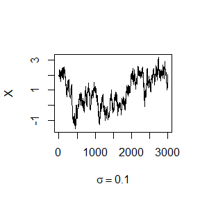

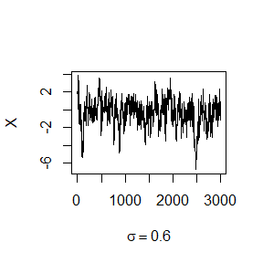

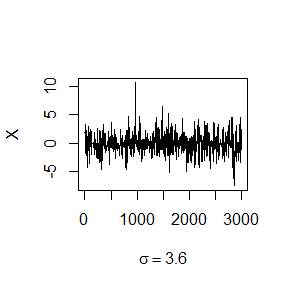

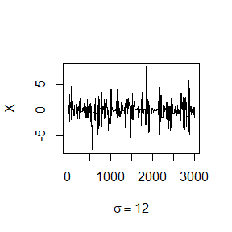

```r
#par(mfrow=c(2,2))
Sample_C = cbind(C_Sample1, C_Sample2, C_Sample3,  C_Sample4)
for (j in 1:4) {
  plot(Sample_C[,j], type="l",
  xlab=bquote(sigma == .(round(sigma[j],3))),
        ylab="X", ylim=range(Sample_C[,j]))
}
```

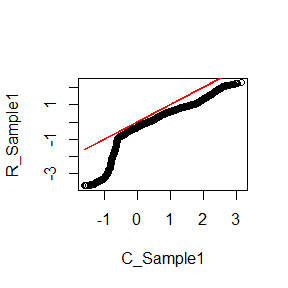

```r
R_Sample1 <- R_Lap(sigma[1],x_1,N)$Sample
R_Sample2 <- R_Lap(sigma[2],x_1,N)$Sample
R_Sample3 <- R_Lap(sigma[3],x_1,N)$Sample
R_Sample4 <- R_Lap(sigma[4],x_1,N)$Sample

#par(mfrow=c(2,2))
qqplot(C_Sample1,R_Sample1)
lines(C_Sample1,C_Sample1,type="l",col="red")
```

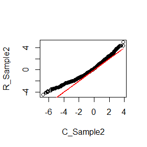

```r
qqplot(C_Sample2,R_Sample2)
lines(C_Sample2,C_Sample2,type="l",col="red")
```

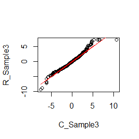

```r
qqplot(C_Sample3,R_Sample3)
lines(C_Sample3,C_Sample3,type="l",col="red")
```

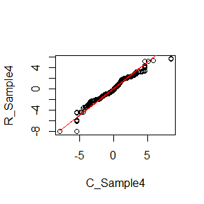

```r
qqplot(C_Sample4,R_Sample4)
lines(C_Sample4,C_Sample4,type="l",col="red")
```

```r
a <- sigma[1]
b <- sigma[2]
c <- sigma[3]
d <- sigma[4]
z <- x_1

microbenchmark::microbenchmark(C_Lap(a,z,N),R_Lap(a,z,N),C_Lap(b,z,N),R_Lap(b,z,N),C_Lap(c,z,N),R_Lap(c,z,N),C_Lap(d,z,N),R_Lap(d,z,N))
```

```
## Unit: microseconds
##            expr    min      lq     mean  median      uq     max neval
##  C_Lap(a, z, N)  451.2  457.35  524.955  463.00  476.95   832.9   100
##  R_Lap(a, z, N) 6066.4 6144.45 7257.249 6249.90 6524.70 16286.9   100
##  C_Lap(b, z, N)  462.7  465.85  537.891  471.20  479.35  2132.3   100
##  R_Lap(b, z, N) 6095.7 6161.95 7169.982 6245.75 6491.10 12421.8   100
##  C_Lap(c, z, N)  473.2  476.55  557.035  483.15  498.55  2143.1   100
##  R_Lap(c, z, N) 6118.4 6195.05 6993.225 6264.70 6474.35 12311.5   100
##  C_Lap(d, z, N)  458.2  465.00  517.617  468.50  475.10  1402.3   100
##  R_Lap(d, z, N) 6125.1 6191.65 7328.390 6274.45 6463.80 16538.8   100
```

### Comment

1 As we can see,if sigma is small ,the Chain 1 from Rcpp function has not converged to the target in 3000 iterations;if sigma is too small or too big,the acceptance rate is not in [0.15,0.5].

2 When sigma become bigger,the bias between C sample and R sample get smaller.

3 According to the result by “microbenchmark”,it’s obvious that the Rcpp function cost less time than R function.The speed of Rcpp function is more than 10 times of R function. In conclusion,the Rcpp function can improve the efficiency in this problem.